# Keine Panik auf der Titanic

Marc Schwering

# 1 Introduction

This is my first Kaggle script so if you see any mistakes, please comment. I used some machine learning in the past but only to solve biological problems, so this is new.

While analyzing the dataset I will go through **Data Preparation**, **Modeling**, and **Prediction**. *Data Preparation* means I look at the data quality, extract features, explore these features, and handle missing values. During *Modeling* the data is shaped for the model class, a form of feature selection is performed, and models are fit. Then the models are analyzed. Finally, the best model is used to make a *Prediction* for the test dataset.

This sounds straight forward but usually it is not. It might happen that I go back and forth bewteen consecutive steps.

**Linear Discriminant Analysis**

Many kernels use logistic regression or random forests as model class. I have not seen someone try out a linear discriminant analysis (LDA) yet. Therefore, this kernel will try to make a prediction using LDA (and its relatives).

**Loading Data**

```r
library(data.table) # database-like tables
library(ggplot2) # general plots
library(lattice) # also for plots
library(mice) # for imputation
library(klaR) # general functions for classification
library(sda) # LDA with special shrinkage method
library(crossval) # for cross validation
```

Let’s load the data. As you can see I belong to the `data.table` people.

```r
test <- read.csv("../input/test.csv")
train <- read.csv("../input/train.csv")
test <- data.table(test)
train <- data.table(train)
str(train)
```

```
## Classes 'data.table' and 'data.frame':   891 obs. of  12 variables:
##  $ PassengerId: int  1 2 3 4 5 6 7 8 9 10 ...
##  $ Survived   : int  0 1 1 1 0 0 0 0 1 1 ...
##  $ Pclass     : int  3 1 3 1 3 3 1 3 3 2 ...
##  $ Name       : Factor w/ 891 levels "Abbing, Mr. Anthony",..: 109 191 358 277 16 559 520 629 416 581 ...
##  $ Sex        : Factor w/ 2 levels "female","male": 2 1 1 1 2 2 2 2 1 1 ...
##  $ Age        : num  22 38 26 35 35 NA 54 2 27 14 ...
##  $ SibSp      : int  1 1 0 1 0 0 0 3 0 1 ...
##  $ Parch      : int  0 0 0 0 0 0 0 1 2 0 ...
##  $ Ticket     : Factor w/ 681 levels "110152","110413",..: 525 596 662 50 473 276 86 396 345 133 ...
##  $ Fare       : num  7.25 71.28 7.92 53.1 8.05 ...
##  $ Cabin      : Factor w/ 148 levels "","A10","A14",..: 1 83 1 57 1 1 131 1 1 1 ...
##  $ Embarked   : Factor w/ 4 levels "","C","Q","S": 4 2 4 4 4 3 4 4 4 2 ...
##  - attr(*, ".internal.selfref")=<externalptr>
```

```r
str(test)
```

```
## Classes 'data.table' and 'data.frame':   418 obs. of  11 variables:
##  $ PassengerId: int  892 893 894 895 896 897 898 899 900 901 ...
##  $ Pclass     : int  3 3 2 3 3 3 3 2 3 3 ...
##  $ Name       : Factor w/ 418 levels "Abbott, Master. Eugene Joseph",..: 210 409 273 414 182 370 85 58 5 104 ...
##  $ Sex        : Factor w/ 2 levels "female","male": 2 1 2 2 1 2 1 2 1 2 ...
##  $ Age        : num  34.5 47 62 27 22 14 30 26 18 21 ...
##  $ SibSp      : int  0 1 0 0 1 0 0 1 0 2 ...
##  $ Parch      : int  0 0 0 0 1 0 0 1 0 0 ...
##  $ Ticket     : Factor w/ 363 levels "110469","110489",..: 153 222 74 148 139 262 159 85 101 268 ...
##  $ Fare       : num  7.83 7 9.69 8.66 12.29 ...
##  $ Cabin      : Factor w/ 77 levels "","A11","A18",..: 1 1 1 1 1 1 1 1 1 1 ...
##  $ Embarked   : Factor w/ 3 levels "C","Q","S": 2 3 2 3 3 3 2 3 1 3 ...
##  - attr(*, ".internal.selfref")=<externalptr>
```

Some classes should be adjusted. (This is the only time I am talking about the data structure. From now on *class* means *survivor* or *non-survivor*)

```r
train[, Name := as.character(Name)]
train[, Ticket := as.character(Ticket)]
train[, Cabin := as.character(Cabin)]
train[, Survived := as.factor(Survived)]
train[, Pclass := as.factor(Pclass)]

test[, Name := as.character(Name)]
test[, Ticket := as.character(Ticket)]
test[, Cabin := as.character(Cabin)]
test[, Pclass := as.factor(Pclass)]
```

# 2 Data Preparation

## 2.1 Data Quality

Here, I basically go through the data and see if there is something important like missing values or weird values. I don’t really look at distributions or correlations yet. This is done in a later section. To keep it short I will only show the stuff that is interesting in some way. For a lot of these features I just did `table` or `summary` to confirm that they look fine.

### 2.1.1 Age

This is the first feature where I found missing values.

```r
summary(train$Age)
```

```
##    Min. 1st Qu.  Median    Mean 3rd Qu.    Max.    NA's
##    0.42   20.12   28.00   29.70   38.00   80.00     177
```

```r
summary(test$Age)
```

```
##    Min. 1st Qu.  Median    Mean 3rd Qu.    Max.    NA's
##    0.17   21.00   27.00   30.27   39.00   76.00      86
```

I guess this is an impotant feature, so probably we have to infer something here. The age range seems reasonable: from 2 months to 80 years old.

### 2.1.2 Fare

```r
summary(train$Fare)
```

```
##    Min. 1st Qu.  Median    Mean 3rd Qu.    Max.
##    0.00    7.91   14.45   32.20   31.00  512.30
```

```r
summary(test$Fare)
```

```
##    Min. 1st Qu.  Median    Mean 3rd Qu.    Max.    NA's
##   0.000   7.896  14.450  35.630  31.500 512.300       1
```

There is one $NA$ *Fare* in the test set.

```r
test[is.na(Fare), ]
```

```
##    PassengerId Pclass               Name  Sex  Age SibSp Parch Ticket Fare
## 1:        1044      3 Storey, Mr. Thomas male 60.5     0     0   3701   NA
##    Cabin Embarked
## 1:              S
```

Also, in both *test* and *train* there are some wildly high values of 512.3. What’s up with these?

```r
train[Fare > 512, ]
```

```
##    PassengerId Survived Pclass                               Name    Sex
## 1:         259        1      1                   Ward, Miss. Anna female
## 2:         680        1      1 Cardeza, Mr. Thomas Drake Martinez   male
## 3:         738        1      1             Lesurer, Mr. Gustave J   male
##    Age SibSp Parch   Ticket     Fare       Cabin Embarked
## 1:  35     0     0 PC 17755 512.3292                    C
## 2:  36     0     1 PC 17755 512.3292 B51 B53 B55        C
## 3:  35     0     0 PC 17755 512.3292        B101        C
```

```r
test[Fare > 512, ]
```

```
##    PassengerId Pclass
## 1:        1235      1
##                                                               Name    Sex
## 1: Cardeza, Mrs. James Warburton Martinez (Charlotte Wardle Drake) female
##    Age SibSp Parch   Ticket     Fare       Cabin Embarked
## 1:  58     0     1 PC 17755 512.3292 B51 B53 B55        C
```

And there were free rides:

```r
train[Fare == 0, ]
```

```
##     PassengerId Survived Pclass                             Name  Sex Age
##  1:         180        0      3              Leonard, Mr. Lionel male  36
##  2:         264        0      1            Harrison, Mr. William male  40
##  3:         272        1      3     Tornquist, Mr. William Henry male  25
##  4:         278        0      2      Parkes, Mr. Francis "Frank" male  NA
##  5:         303        0      3  Johnson, Mr. William Cahoone Jr male  19
##  6:         414        0      2   Cunningham, Mr. Alfred Fleming male  NA
##  7:         467        0      2            Campbell, Mr. William male  NA
##  8:         482        0      2 Frost, Mr. Anthony Wood "Archie" male  NA
##  9:         598        0      3              Johnson, Mr. Alfred male  49
## 10:         634        0      1    Parr, Mr. William Henry Marsh male  NA
## 11:         675        0      2       Watson, Mr. Ennis Hastings male  NA
## 12:         733        0      2             Knight, Mr. Robert J male  NA
## 13:         807        0      1           Andrews, Mr. Thomas Jr male  39
## 14:         816        0      1                 Fry, Mr. Richard male  NA
```

[output cut: 17 more lines]

```r
test[Fare == 0, ]
```

```
##    PassengerId Pclass                                  Name  Sex Age SibSp
## 1:        1158      1 Chisholm, Mr. Roderick Robert Crispin male  NA     0
## 2:        1264      1               Ismay, Mr. Joseph Bruce male  49     0
##    Parch Ticket Fare       Cabin Embarked
## 1:     0 112051    0                    S
## 2:     0 112058    0 B52 B54 B56        S
```

The cases with $Fare = 0$ also have a lot of missing values for *Age*. I wonder whether `0` also denotes to a missing value for *Fare*.

### 2.1.3 Cabin

```r
head(train$Cabin)
```

```
## [1] ""     "C85"  ""     "C123" ""     ""
```

```r
head(test$Cabin)
```

```
## [1] "" "" "" "" "" ""
```

```r
table(train$Cabin == "")
```

```
##
## FALSE  TRUE
##   204   687
```

```r
table(test$Cabin == "")
```

```
##
## FALSE  TRUE
##    91   327
```

This looks bad. Most are empty.

### 2.1.4 Embarked

```r
table(train$Embarked)
```

```
##
##       C   Q   S
##   2 168  77 644
```

```r
train[Embarked == "", ]
```

```
##    PassengerId Survived Pclass                                      Name
## 1:          62        1      1                       Icard, Miss. Amelie
## 2:         830        1      1 Stone, Mrs. George Nelson (Martha Evelyn)
##       Sex Age SibSp Parch Ticket Fare Cabin Embarked
## 1: female  38     0     0 113572   80   B28
## 2: female  62     0     0 113572   80   B28
```

In the training set there are 2 empty *Embarked* entries. Both survived, maybe they didn’t embark.

### 2.1.5 Summary

- *Age*: many $NA$ in test and train
- *Fare*: 1 $NA$ in test, several 0’s
- *Cabin*: many empty strings in test and train
- *Embarked*: 2 empty strings in train

## 2.2 Feature Extraction

In general one could use some of these features already as they are. Now I see if I can extract some more features. This is quite exploratory. I go through the training set and see what I can do.

### 2.2.1 Names

I am starting with the *Names* column. Obviously one can extract *Surnames* and *Titles* from the names. The idea for the following code is taken from `mrisdal`’s Titanic kernel. Titles and surnames are extracted from the *Names* column. To reduce the number of titles a label *Rare Title* is created. It marks all titles that did not appear that often.

**Titles**

```r
train$Title <- gsub('(.*, )|(\\..*)', '', train$Name)
table(train$Title)
```

```
##
##         Capt          Col          Don           Dr     Jonkheer
##            1            2            1            7            1
##         Lady        Major       Master         Miss         Mlle
##            1            2           40          182            2
##          Mme           Mr          Mrs           Ms          Rev
##            1          517          125            1            6
##          Sir the Countess
##            1            1
```

```r
rare_title <- c('Dona', 'Lady', 'the Countess','Capt', 'Col', 'Don',
                'Dr', 'Major', 'Rev', 'Sir', 'Jonkheer')
train[Title == "Mlle", Title := "Miss"]
train[Title == "Ms", Title := "Miss"]
train[Title == "Mme", Title := "Mrs"]
train[Title %in% rare_title, Title := "Rare Title"]
```

```r
table(train$Title, train$Sex)
```

```
##
##              female male
##   Master          0   40
##   Miss          185    0
##   Mr              0  517
##   Mrs           126    0
##   Rare Title      3   20
```

**Surnames**

The idea for this part is also form `mrisdal`.

```r
train$Surname <- vapply(
  train$Name,
  function(x) strsplit(x, "[,. ]")[[1]][1],
  character(1)
)
length(unique(train$Surname))
```

```
## [1] 661
```

```r
any(train$Surname == "")
```

```
## [1] FALSE
```

**Surname Count**

I thought it would also be useful to have the number of people with identical surnames aboard as a feature. This might help later on when identifying families.

```r
counts <- table(train$Surname)
train$SNCount <- vapply(
  train$Surname,
  function(sn) counts[names(counts) == sn],
  integer(1)
)
table(train$SNCount)
```

```
##
##   1   2   3   4   5   6   7   9
## 525 170  81  64   5  30   7   9
```

### 2.2.2 Age

One important factor for survival is definitely the age. As far as I know women and children were the first to board the rescue boats. So, there should be a natural separation at age of 18. I will extract this as a binary feature.

```r
train$isChild <- as.integer(train$Age < 18)
table(train$isChild)
```

```
##
##   0   1
## 601 113
```

### 2.2.3 Families

Families probably stayed together. So knowning the families would be good for prediction. Using cabin information, Sibling/Spouses and Parent/Children, and the names one could try to link family members. For now I will just extract the general family size.

```r
train$FMembers <- train$SibSp + train$Parch + 1
table(train$FMembers)
```

```
##
##   1   2   3   4   5   6   7   8  11
## 537 161 102  29  15  22  12   6   7
```

### 2.2.4 Ticket Text

The tickets are not only numbers.

```r
txt <- toupper(gsub("[0-9\\. /]", "", train$Ticket))
table(txt)
```

```
## txt
##                   A        AS         C        CA   CASOTON        FA
##       661        28         1         5        41         1         1
##        FC       FCC      LINE        PC        PP       PPP        SC
##         1         5         4        60         3         2         1
##       SCA      SCAH SCAHBASLE      SCOW   SCPARIS       SOC       SOP
##         1         2         1         1        11         6         1
##      SOPP    SOTONO   SOTONOQ        SP     STONO      SWPP        WC
##         3         2        15         1        18         2        10
##       WEP
##         3
```

This seems to tell me the embarkment as well. But this factor has to many levels in my opinion. I will keep the most abundant levels and try to allocate the others by similarity (that’s quite subjective). For the ones I don’t know how to allocate I will create a label *other*.

```r
table(txt)[table(txt) > 10]
```

```
## txt
##               A      CA      PC SCPARIS SOTONOQ   STONO
##     661      28      41      60      11      15      18
```

```r
txt[txt == "AS"] <- "A"
txt[txt %in% c("C", "CASOTON")] <- "CA"
txt[txt %in% c("PC", "PPP", "PP")] <- "PC"
txt[txt %in% c("SC", "SCA")] <- "SCPARIS"
txt[txt %in% c("SOTONOQ", "STONO")] <- "SOTONO"
txt[!(txt %in% c("", "SOTONO", "SCPARIS", "PC", "CA"))] <- "other"
train$TicketText <- txt
table(train$TicketText)
```

```
##
##              CA   other      PC SCPARIS  SOTONO
##     661      47      70      65      13      35
```

### 2.2.5 Cabins

The Cabin feature is very sparse. However, for those that have values, we can extract the deck symbol and the number of cabins listed on the ticket.

**Deck**

The highest deck should be *A*, the one below *B*, and so on. The first character in the *Cabin* number is the deck.

```r
train$Deck <- vapply(
  train$Cabin,
  function(x) strsplit(x, "")[[1]][1],
  character(1)
)
train[is.na(Deck), Deck := ""]
```

```r
table(train$Deck)
```

```
##
##       A   B   C   D   E   F   G   T
## 687  15  47  59  33  32  13   4   1
```

**Number of Cabins**

In some cases several cabins are listed. Maybe that will be important.

```r
train$nCabins <- vapply(
  train$Cabin,
  function(x) length(strsplit(x, " ")[[1]]),
  integer(1)
)
table(train$nCabins)
```

```
##
##   0   1   2   3   4
## 687 180  16   6   2
```

For the people who do not have a cabin I will also create a binary feature.

```r
train$hasCabin <- train$nCabins > 0
```

## 2.3 Feature Exploration

In this section I will look at feature distributions and correlations. This information is useful when constructing the final features for the model.

As said before I want to use linear discriminant analyses and related models. It is known how these behave to certain data structures. Highly correlated features for example can produce unstable coefficient estimates. In general I will explore different combination of features in the **Modeling** section anyway. But it is good to know the features in order to explain why certain models perform better than others.

Another thing is, that I might need to adjust some features. A regular LDA for example assumes Gauss distributed features. So, sometimes it makes sense to use transformations of a feature instead of the raw feature.

Again, this is not a straight forward process. I might extract some more features along the way. Usually, I would go through each feature and look for correlation to (almost) every other feature. To keep it short I will only print the inetresting plots and give a summary at the end.

### 2.3.1 Numeric Features Overview

At first I like to look at all numeric features, their correlation among each others and their influence on the target variable. A scatter plot matrix (SPLOM) is good for that. In the following scatter plot matrix blue indicates *survived*.

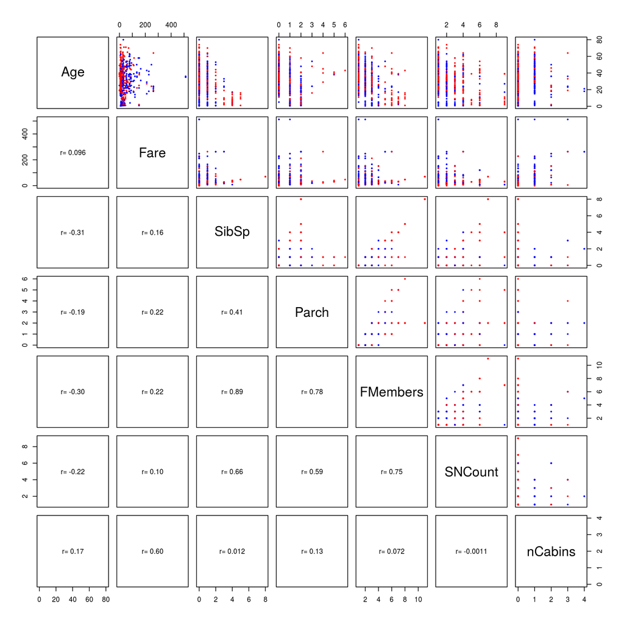

```r
# color palette for Survived label
pal <- c("red", "blue")

# pearson corelation coefficients for SPLOM
panel.cor <- function(x, y, digits = 2, cex.cor, ...) {
  usr <- par("usr"); on.exit(par(usr))
  par(usr = c(0, 1, 0, 1))
  m <- cbind(x, y)
  m <- m[complete.cases(m), ]
  r <- cor(m[, 1], m[, 2])
  txt <- format(c(r, 0.123456789), digits = digits)[1]
  txt <- paste("r= ", txt, sep = "")
  text(0.5, 0.5, txt)
}

# SPLOM
pairs(
  train[, .(Age, Fare, SibSp, Parch, FMembers, SNCount, nCabins)],
  col = pal[train$Survived],
  pch = 20,
  cex = 0.5,
  lower.panel = panel.cor
)
```

For discrete values one should be careful with the interpretation of these scatter plots. These few points that can be seen in distinct places are in reality many points plotted on top of each other. The pearson correlation coefficients are still useful though.

For obvious reasons there is a high correlation between *SibSp* and *FMembers*, and *Parch* and *FMembers* (created from each other). There is also a high correlation between *FMembers* and *SNCount*. The correlation of *SNCount* to either *SibSp* or *Parch* is moderately high.

The remaining feature pairs do not show high correlations.

### 2.3.2 Age

Let’s see if the age has a substantial effect on survival chances. Densities are good for such comparisons. They integrate to 1 which means distributions of 2 features with different total counts can nicely be compared. Second, they use a kernel for local smoothing. This way only the local trend is visible.

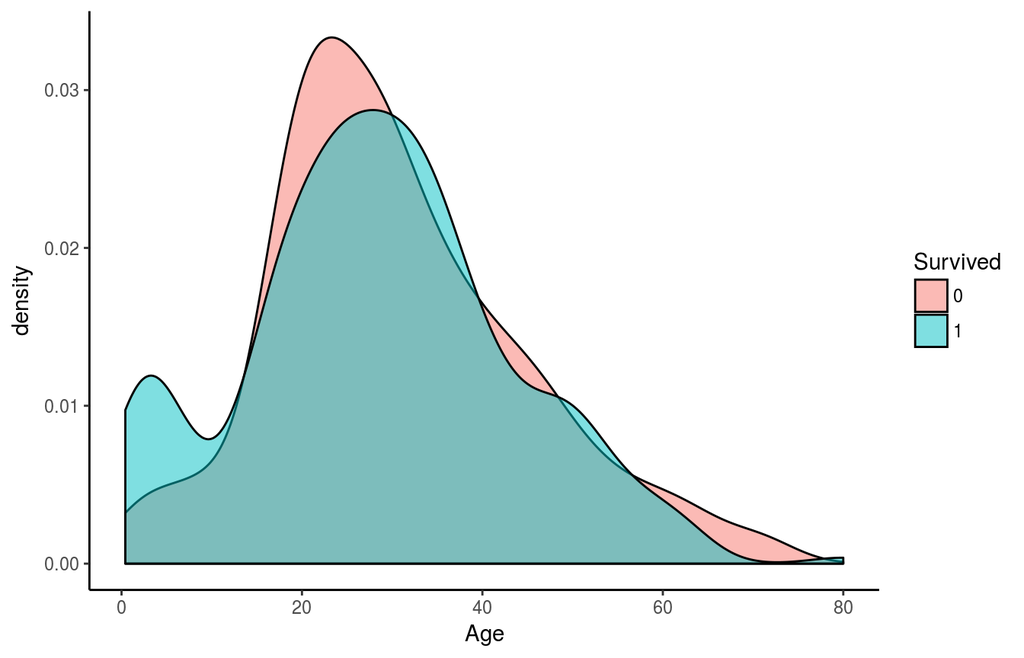

```r
ggplot(train, aes(x = Age, fill = Survived)) +
  geom_density(alpha = .5) +
  theme_classic()
```

For both survivors and non-survivors the age distribution looks very similar. There seems to be just one clear trend change between age 0 and 20. This is probably because children boarded first.

However, from this plot I can’t say whether this separation is really at the age of 18. The proportion difference of survivors and non-survivors in 2 age groups might be a useful indicator. I will look at these proportions while adjusting the separation age.

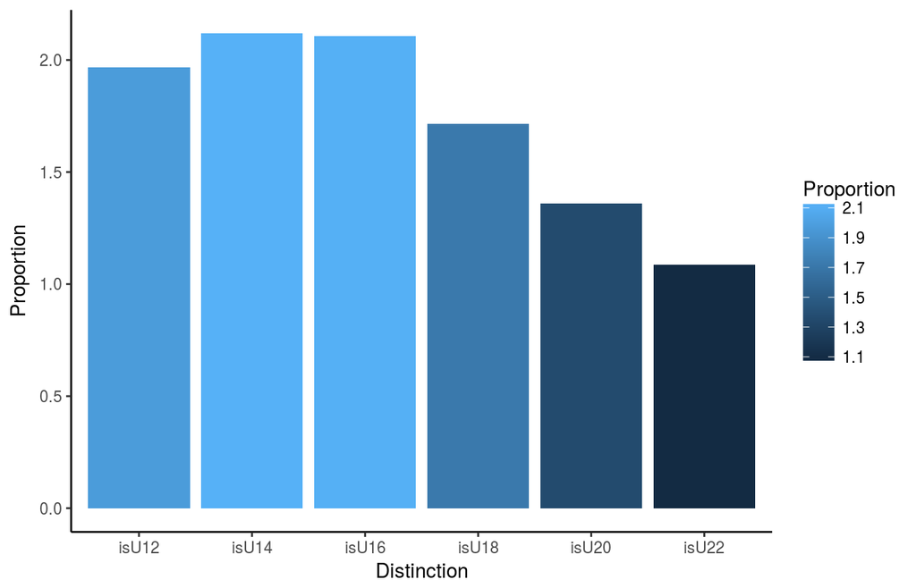

```r
dt <- train[!is.na(train$Age),
            .(isU12 = Age < 12, isU14 = Age < 14,
              isU16 = Age < 16, isU18 = Age < 18,
              isU20 = Age < 20, isU22 = Age < 22,
              Survived)]
dt <- dt[,
   .(isU12 = sum(isU12) / length(isU12), isU14 = sum(isU14) / length(isU14),
     isU16 = sum(isU16) / length(isU16), isU18 = sum(isU18) / length(isU18),
     isU20 = sum(isU20) / length(isU20), isU22 = sum(isU22) / length(isU22)),
   by = Survived]
dt <- melt(dt, measure.vars = 2:7, variable.name = "Distinction",
           value.name = "People")
f <- function(x) { x[2] / x[1] }
dt <- dt[, .(Proportion = f(People)), by = Distinction]
ggplot(dt, aes(x = Distinction, y = Proportion, fill = Proportion)) +
  geom_bar(position = "dodge", stat = "identity") +
  theme_classic()
```

According to this plot, 18 would not be a good age to group children and adults. Groups should be divided at the age of 14.

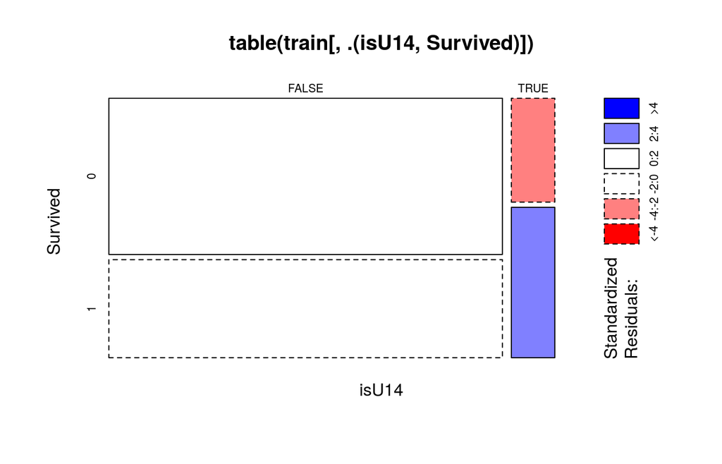

```r
train$isU14 <- train$Age < 14
mosaicplot(table(train[, .(isU14, Survived)]), shade = TRUE)
```

The mosaic plot visualizes the contingency table of 2 factors as rectangles. The color here shows the residuals of a model which assumes independence of both factors. So, the more colorful the rectangles, the less they can be explained by a independence model. Here, this means feature *isU14* seems to explain the variability in *Survived* to some degree.

### 2.3.3 Families

**SibSp**

To visualize the distribution of discrete features I will use bar plots.

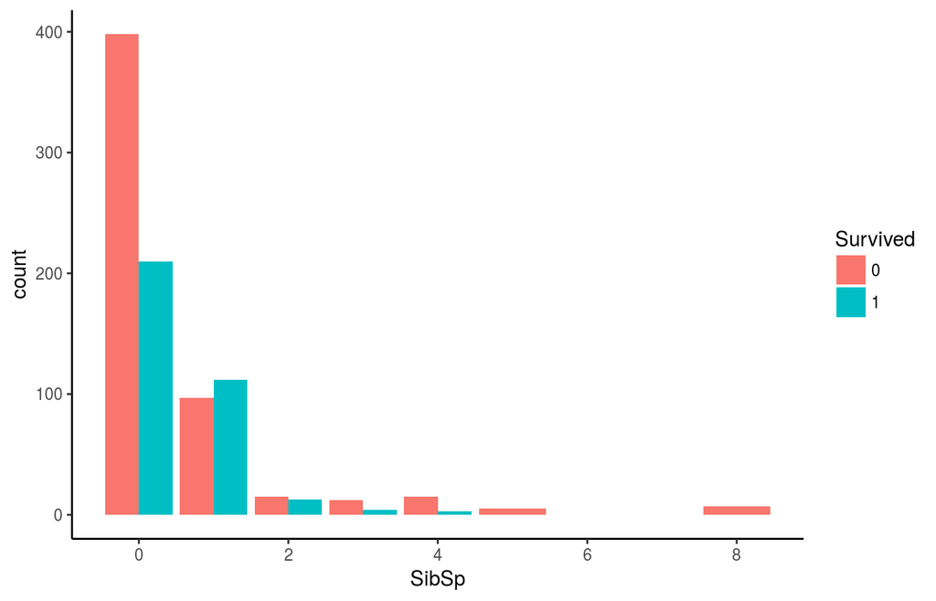

```r
ggplot(train, aes(x = SibSp, fill = Survived)) +
  geom_bar(position = "dodge") +
  theme_classic()
```

Both classes (*survivor*/ *non-survivor*) show similar trends but the proportions seem to differ. This is easier to see in a mosaic plot.

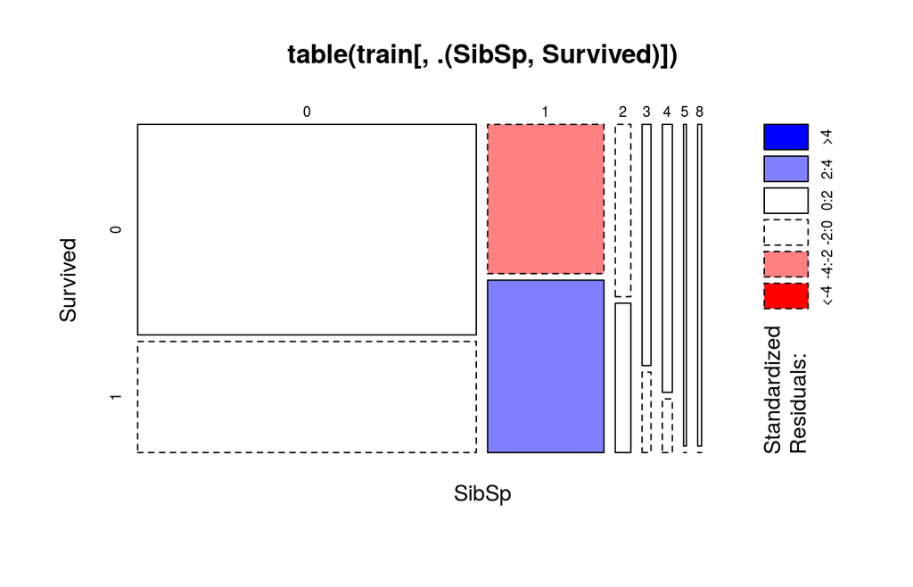

```r
mosaicplot(table(train[, .(SibSp, Survived)]), shade = TRUE)
```

It seems that large families in general had lower survival chances. Passengers with 1 spouse/sibling had the highest survival chances. But then people with zero spouses/sibling had lower survival chances again.

Maybe families in general had higher survival chances because there were children involved. But then for the larger families it was harder to get every one together in the chaos and that’s why they again have lower survival chances. (my theory for this…)

A linear separator would not be able to distinguish this drop at 0 again. Therefore, I create a binary feature to only capture the $SibSp = 1$ cases.

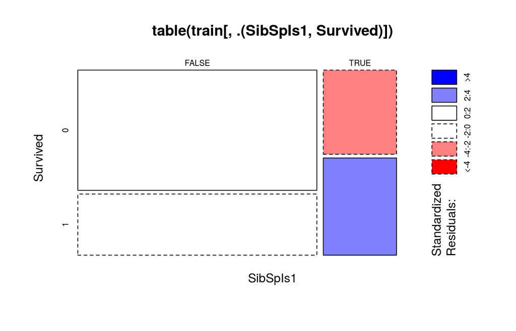

```r
train$SibSpIs1 <- train$SibSp == 1
mosaicplot(table(train[, .(SibSpIs1, Survived)]), shade = TRUE)
```

**Parch, FMembers, SNCount**

To make it short: There are similar trends in the family related features. I always extract the cases with highest survival rate as a binary feature.

```r
train$ParchIs1 <- train$Parch == 1
train$smallFamily <- train$FMembers > 1 & train$FMembers < 5
train$SNCountIs2 <- train$SNCount == 2
```

### 2.3.4 Fare

This feature can be spread out better by a log transformation. The log10 seems natural for money.

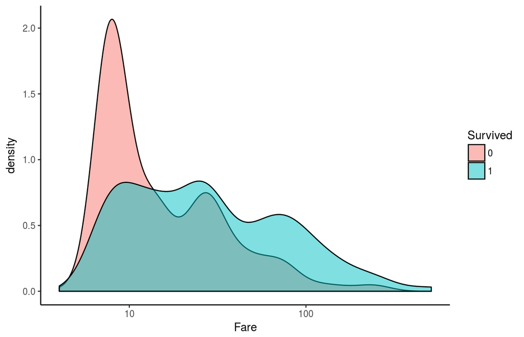

```r
ggplot(train, aes(x = Fare, fill = Survived)) +
  geom_density(alpha = .5) +
  scale_x_continuous(trans = "log10") +
  theme_classic()
```

It looks like survival chances were higher with a more expensive ticket. The capitalism is strong with this one.

```r
train$lFare <- log10(train$Fare + 1)
```

### 2.3.5 Pclass

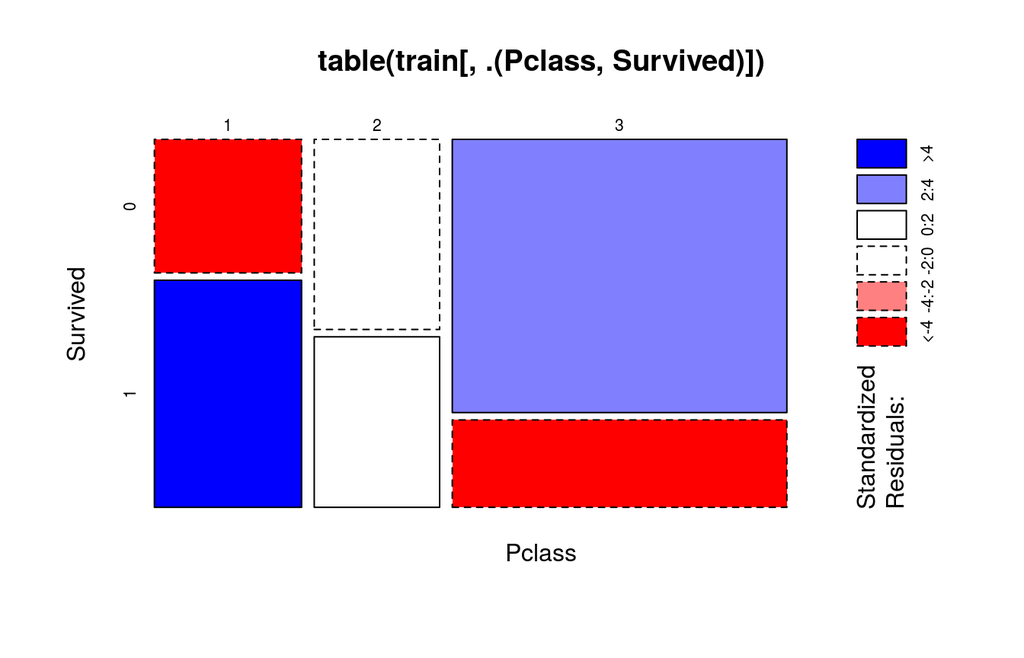

```r
mosaicplot(table(train[, .(Pclass, Survived)]), shade = TRUE)
```

This feature looks useful. Higher classes had better survial chances.

### 2.3.6 Ticket Text

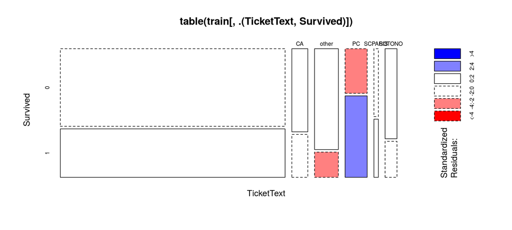

```r
mosaicplot(table(train[, .(TicketText, Survived)]), shade = TRUE)
```

The *PC* label seems to be a useful information. I will make a feature for this.

```r
train$isPC <- train$TicketText == "PC"
```

### 2.3.7 Deck

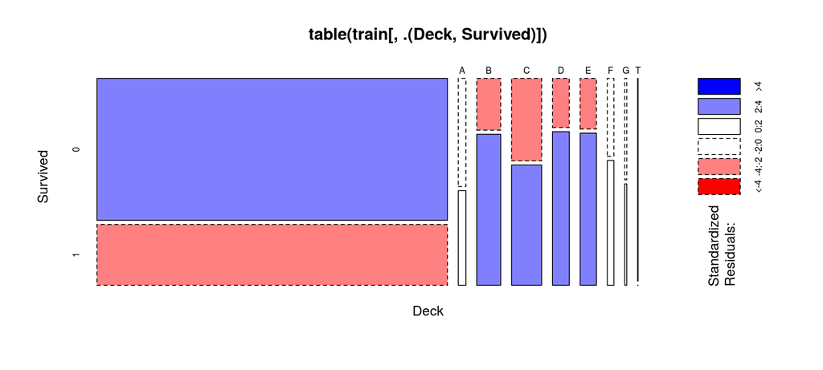

```r
mosaicplot(table(train[, .(Deck, Survived)]), shade = TRUE)
```

Having no deck seems to be an indicator for low survival chances.

```r
train$noDeck <- train$Deck == ""
```

### 2.3.8 Cabins

I did not see a trend in the number of cabins, only that having no cabin is a bad omen.

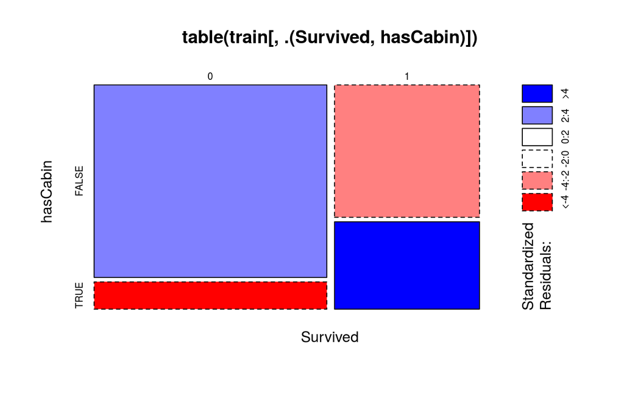

```r
mosaicplot(table(train[, .(Survived, hasCabin)]), shade = TRUE)
```

### 2.3.9 Embarked

Interestingly, people embarking from Cherbourg had higher survival chances.

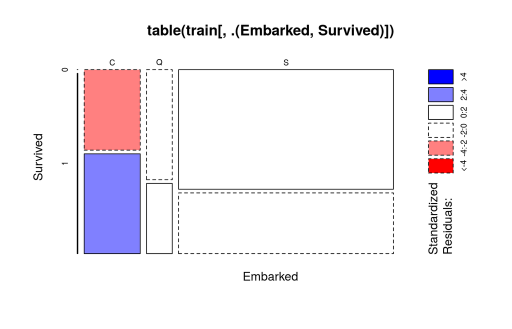

```r
mosaicplot(table(train[, .(Embarked, Survived)]), shade = TRUE)
```

```r
train$fromC <- train$Embarked == "C"
```

### 2.3.10 Sex

I think this one is obvious.

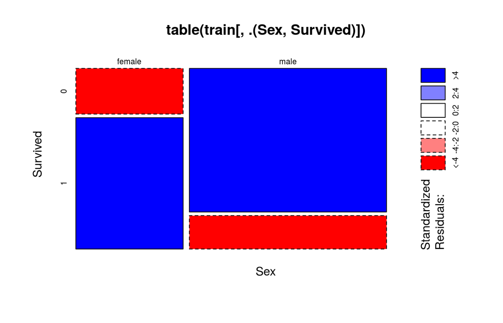

```r
mosaicplot(table(train[, .(Sex, Survived)]), shade = TRUE)
```

### 2.3.11 Title

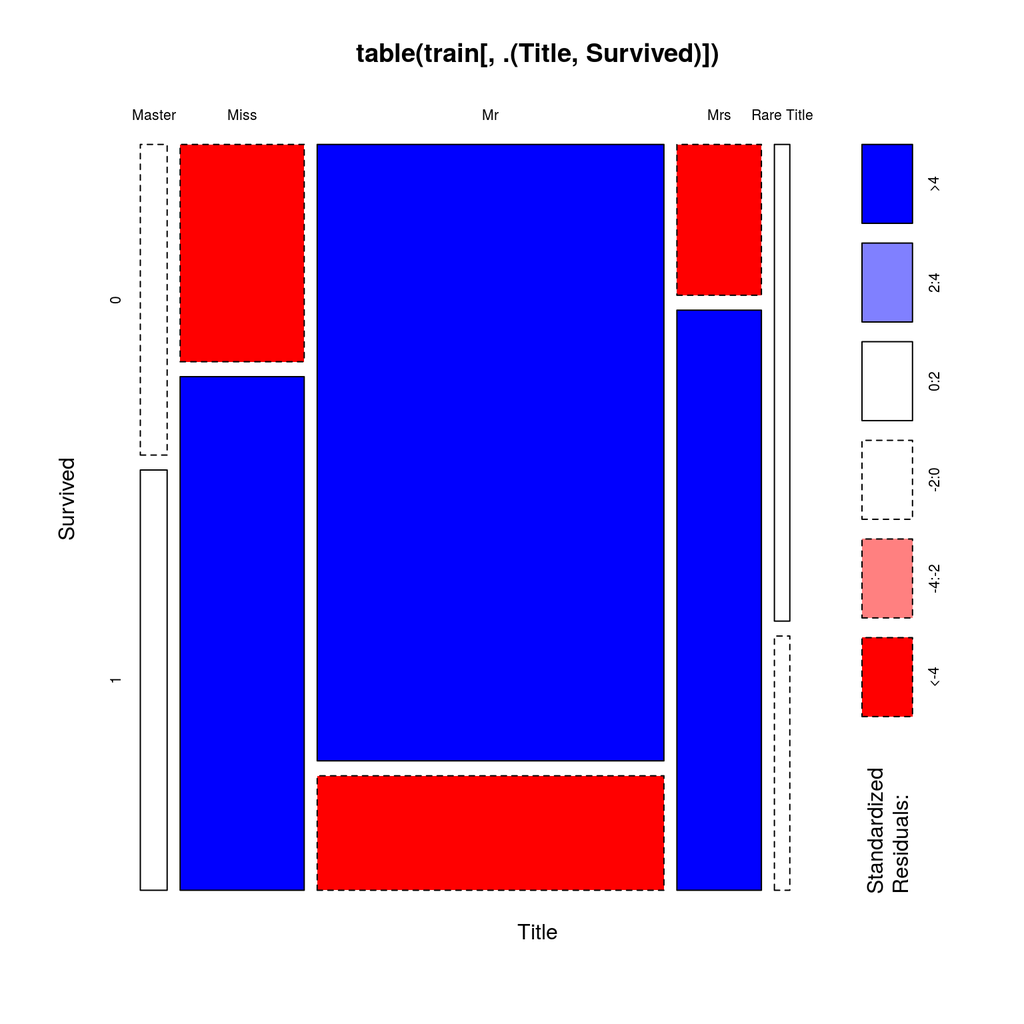

```r
mosaicplot(table(train[, .(Title, Survived)]), shade = TRUE)
```

Well, needless to say the female titles had higher survival chances. The interesting thing here is that *Master* and *Rare Title* have different survival chances than *Mr*. Ok *Rare Title* also includes females, but *Master* is a male-only title.

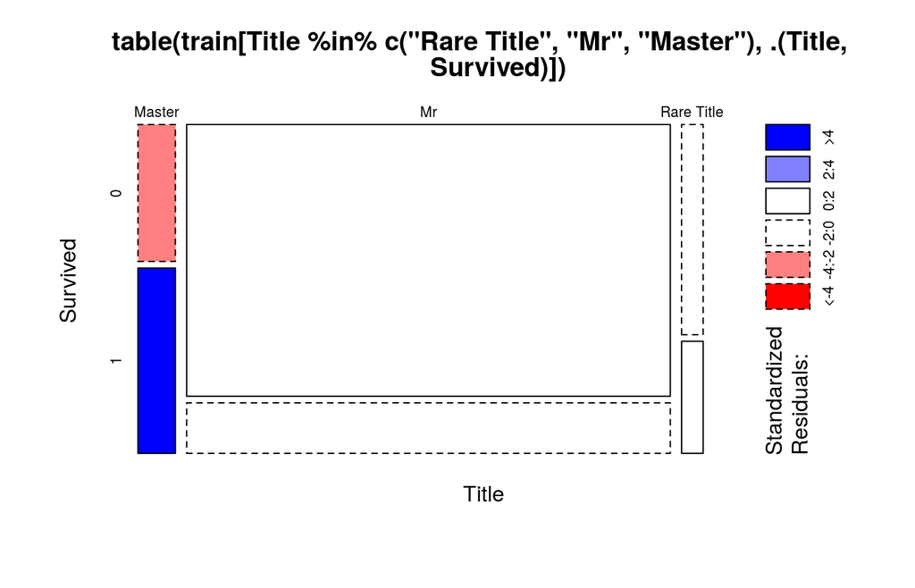

```r
mosaicplot(table(train[Title %in% c("Rare Title", "Mr", "Master"),
                   .(Title, Survived)]), shade = TRUE)
```

```r
train$isMaster <- train$Title == "Master"
```

### 2.3.12 Summary

**To Target**

- *Age*: for $Age \geq 14$ similar distributions among classes; for $Age \lt 14$ more survivors
- Families as represented by *SibSp*, *Parch*, *FMembers*, *SNCount*: large families have lower survival chances
- *Fare*: higher fares have higher survival chances
- *Pclass*: higher passenger classes have higher survival chances
- *isPC*: $TicketText = PC$ means higher survival chances
- *hasCabin*: having no cabin means lower survival chances
- *fromC*: people from Cherbourg had higher survival chances
- *Sex*: females had higher survival chances
- *isMaster*: higher survival chance with title *Master*

## 2.4 Missing Values

### 2.4.1 Fare

There was 1 $NA$ for *Fare* in the test set. Since this is just 1 value I think it is reasonable to set it to the median.

```r
test[is.na(Fare), Fare := median(c(test$Fare, train$Fare), na.rm = TRUE)]
```

### 2.4.2 Embarked

In the train set there were 2 empty strings. I saw many people label it with *C* because of the high fare (80) of these passenger tickets. Below is a violin plot that shows *Fare* densities for the *Embarked* variable.

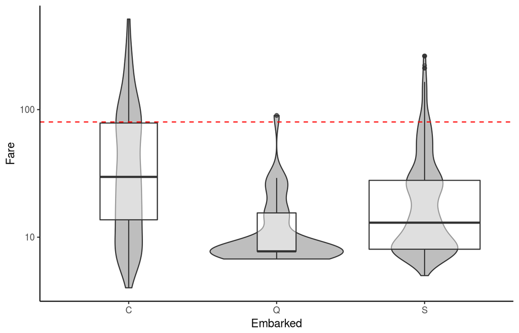

```r
ggplot(train[!Embarked == ""], aes(x = Embarked, y = Fare)) +
  geom_violin(fill = "gray") +
  geom_boxplot(alpha = .5, varwidth = TRUE) +
  geom_hline(yintercept = 80, color = "red", linetype = 2) +
  scale_y_continuous(trans = "log10") +
  theme_classic()
```

The y-axis is log transformed to see the spread of *Fare* better. The red line is drawn for $Fare = 80$. Clearly, it seems unlikely that the passengers embarked in *Q*. *C* seems slightly more likely than *S* according to the densities. However, you can also see the prior probabilities of *Embarked*. With `varwidth = TRUE` the boxplot widths are proportional to the square roots of the groups counts.

```r
prop.table(table(as.character(train[!Embarked == "", Embarked])))
```

```
##
##          C          Q          S
## 0.18897638 0.08661417 0.72440945
```

Taking this into account I would rather set these two values to *S*

```r
train[Embarked == "", Embarked := "S"]
```

### 2.4.3 Age

There were many $NA$s in *Age* and probably this is an important variable. At least it is important to know whether or not a passenger was a child. In other kernels I saw people using the `mice` package. I didn’t know this one before but it sounds quite powerful.

It does multiple imputations using chained equations. I’m not so familiar with imputation but there are two general ways to do imputation. One is to impute variables one at a time. The other (Joint Modeling) is do impute these variables simultaneously. This package does the first one. As the name says it does this multiple times (by default 5 times). This assures that the uncertainty of the data that is imputed is kept. For the imputation, a set of seamingly useful variables can be defined.

```r
full <- rbind(
  train[, .(Age, Pclass, Sex, lFare, Parch, SibSp)],
  test[, .(Age, Pclass, Sex, lFare = log10(Fare + 1), Parch, SibSp)]
)
imp <- mice(full, seed = 42)
```

```r
imp
```

```
## Multiply imputed data set
## Call:
## mice(data = full, seed = 42)
## Number of multiple imputations:  5
## Missing cells per column:
##    Age Pclass    Sex  lFare  Parch  SibSp
##    263      0      0      0      0      0
## Imputation methods:
##    Age Pclass    Sex  lFare  Parch  SibSp
##  "pmm"     ""     ""     ""     ""     ""
## VisitSequence:
## Age
##   1
## PredictorMatrix:
##        Age Pclass Sex lFare Parch SibSp
## Age      0      1   1     1     1     1
## Pclass   0      0   0     0     0     0
## Sex      0      0   0     0     0     0
## lFare    0      0   0     0     0     0
## Parch    0      0   0     0     0     0
## SibSp    0      0   0     0     0     0
## Random generator seed value:  42
```

The summary tells us that 263 values for *Age* were imputed from *Pclass*, *Sex*, *lFare*, *Parch*, and *SibSp*. The method used was predictive mean matching. 5 datasets have been created. The plot below shows these datasets. Blue values in all plots are identical, the red ones were the imputed ones. The imputed points visibly resemble the distribution of the real points.

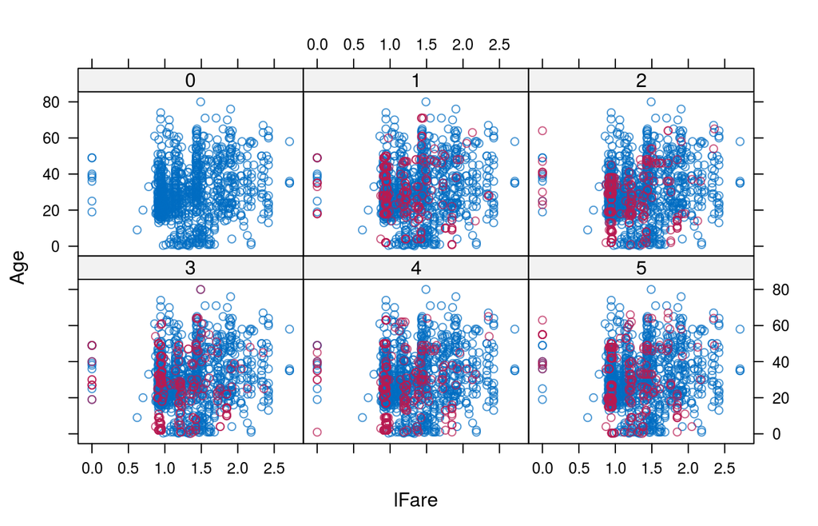

```r
xyplot(imp, Age ~ lFare | .imp)
```

The idea of the package is to continue fitting the model on all 5 datasets and then pool the results back together. Here, I will only use the imputed values of 1 dataset though.

```r
impAge <- complete(imp)$Age
```

# 3 Modeling

In this section I will create the input matrix ($X$) and fit different models to it. To estimate the prediction error of these models cross validation is used. The best Model will ultimately be chosen for the prediction.

## 3.1 Create Input Matrix

First, I need to create the input matrix. I will call it $X$ as in $Y = f(X) + \epsilon$, where $f$ is the model with input $X$, output $Y$, and error $\epsilon$. The input matrix has the form $N \times p$ with $N$ rows (the observations) and $p$ columns (the features or predictor variables). $Y$ is a class indicator matrix of $N \times 1$ where $0$ indicates *non-survivor* and $1$ indicates *survivor*

In the previous section I carelessly created new features. The assumptions that I made were based on complete data. Then, I used imputation to replace missing values. Now, I have to do the feature extraction again in a proper way. It should include imputed data and it should be aplicable on the test and train set. I will write a function for this. The function should take the datasets and return a ready-to-use numeric input matrix. For categorical features I have to create dummy variables.

```r
MakeX <- function(train, test,
                  naFare = 80, naEmbarked = "S", naAge = impAge) {
  # combine datasets
  keepCols <- c("PassengerId", "Pclass", "Name", "Sex", "Age", "SibSp",
                "Parch", "Ticket", "Fare", "Cabin", "Embarked")
  train <- train[, keepCols, with = FALSE]
  test <- test[, keepCols, with = FALSE]
  full <- rbind(train, test)

  # impute missing values
  full[is.na(Fare), Fare := naFare]
  full[Embarked == "", Embarked := naEmbarked]
  full[, Age := impAge]

  # extract features from Names
  titles <- gsub('(.*, )|(\\..*)', '', full$Name)
  surnames <- vapply(
    full$Name,
    function(x) strsplit(x, "[,. ]")[[1]][1],
    character(1)
  )
  full$isMaster <- titles == "Master"
  counts <- table(surnames)
  full$SNCount <- vapply(
    surnames,
    function(sn) counts[names(counts) == sn],
    integer(1)
  )

  # extract features from Age
  full$isU14 <- full$Age < 14
  full$isU18 <- full$Age < 18

  # dummy for sex
  full$isMale <- full$Sex == "male"

  # extract Family features
  full$FMembers <- full$SibSp + full$Parch + 1
  full$SibSpIs1 <- full$SibSp == 1
  full$ParchIs1 <- full$Parch == 1
  full$smallFamily <- full$FMembers > 1 & full$FMembers < 5
  full$SNCountIs2 <- full$SNCount == 2

  # transform Fare
  full$lFare <- log10(full$Fare + 1)

  # extract Ticket feature
  txt <- toupper(gsub("[0-9\\. /]", "", full$Ticket))
  full$isPC <- txt %in% c("PC", "PPP", "PP")

  # extract Cabin features
  full$Deck <- vapply(
    full$Cabin,
    function(x) strsplit(x, "")[[1]][1],
    character(1)
  )
  full[is.na(Deck), Deck := ""]
  full$noDeck <- full$Deck == ""
  full$nCabins <- vapply(
    full$Cabin,
    function(x) length(strsplit(x, " ")[[1]]),
    integer(1)
  )
  full$hasCabin <- full$nCabins > 0

  # extract Embarked features
  full$fromC <- full$Embarked == "C"
  full$fromQ <- full$Embarked == "Q"

  # make X
  keepCols <- c("Pclass", "isMale", "Age", "isU14", "SibSp", "SibSpIs1",
                "Parch", "ParchIs1", "FMembers", "smallFamily", "SNCount",
                "SNCountIs2", "isPC", "Fare", "lFare", "nCabins", "hasCabin",
                "noDeck", "fromC", "fromQ")
  l <- lapply(keepCols, function(colName) { as.integer(full[[colName]]) })
  X <- do.call(cbind, l)
  rownames(X) <- full$PassengerId
  colnames(X) <- keepCols

  return(X)
}
```

With this I create X and split it back into test and training again.

```r
X <- MakeX(train, test)
Xtrain <- X[1:nrow(train), ]
Xtest <- X[-(1:nrow(train)), ]
Ytrain <- as.integer(as.character(train$Survived))
```

## 3.2 LDA

A linear discriminant analysis wants to see the data points of each class as a multivariate Gauss cloud. It wants to maximize the distances between the clouds’ centroids with respect to their spreads. In a regular LDA it is assumed that the covariance matrices of all classes are the same. So, for estimating the covariance matrix, all data points are pooled. With this assumption separating hyperplanes between classes are always linear.

To get an idea what the LDA *sees* we can plot the class distributions along the 1st discriminant coordinate. For 2 classes this is the orthogonal of the separating hyperplane. As you can see below, there is a big overlap. We can exppect a high error rate.

```r
fit <- lda(Xtrain, Ytrain)
```

```
## Warning in lda.default(x, grouping, ...): variables are collinear
```

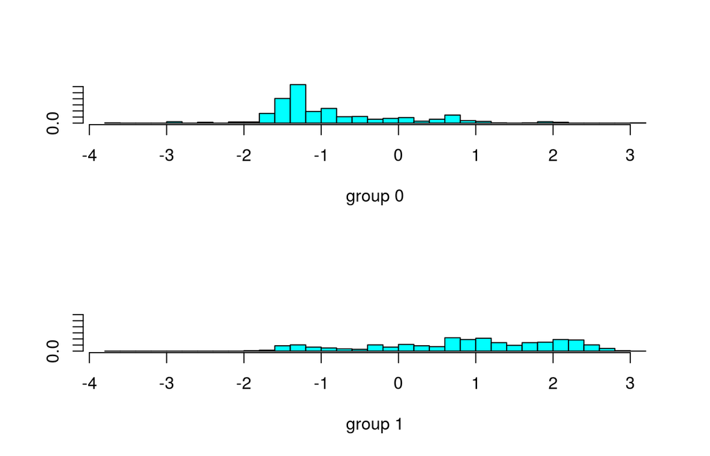

```r
plot(fit)
```

The warning about colinear variables is what I mentioned during data preparation. A variable that is colinear to another variable does not bring a lot of new information. But it brings a lot of variance because its coefficient estimates are unstable. That’s why it makes sense to kick out some variables – introducing bias in order to reduce variance.

The function below does a forward feature selection. A model is built stepwise by starting at only an intercept and successivly adding a variable. Variable selection is done by minimizing the error rate, which is in turn estimated by 10-fold cross validation. This method is nested and greedy. I set `improvement = -1` so it will not stop until all variables were included.

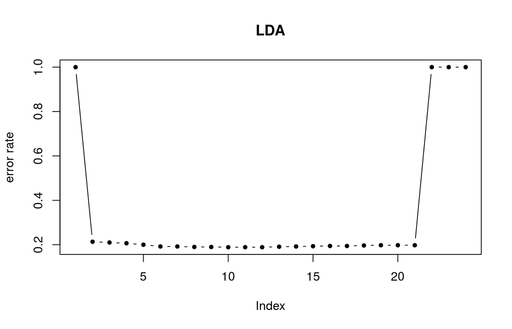

```r
stepsLDA <- stepclass(Xtrain, grouping = Ytrain,
                   improvement = -1, method = "lda", direction = "forward")
plot(1 - stepsLDA$process$result.pm, type = "b", pch = 20,
     ylab = "error rate", main = "LDA")
```

According to this method there are at least 5 features which I should include and at least 5 features which I should not include. The feature combination with the lowest error rate is…

```r
idx <- which.max(stepsLDA$process$result.pm)
as.character(stepsLDA$process$varname[1:idx])
```

```
##  [1] "--"          "isMale"      "SibSp"       "smallFamily" "Pclass"
##  [6] "Parch"       "isU14"       "SNCount"     "ParchIs1"    "lFare"
```

Eventually I want to put the model selection process into a cross validation. Therefore, I write feature selection and the model fitting as a function. I will do a forward selection again, but this time I set `improvement = 0` to stop as soon as the error rate goes up again. I will also reduce set `fold = 5` in `stepclass()` to speed up the whole process.

```r
predLDA <- function(trainX, trainY, testX, testY) {
  # estimate best feature combination with CV
  steps <- stepclass(
    trainX, grouping = trainY,
    improvement = 0, method = "lda", direction = "forward",
    fold = 5, output = FALSE
  )

  # fit model with selected features
  idx <- which.max(steps$process$result.pm)
  feats <- as.character(steps$process$varname[1:idx])
  trainX <- trainX[, colnames(trainX) %in% feats[-1]]
  fit <- lda(trainX, grouping = trainY)

  # make prediction and return accuracy
  testX <- testX[, colnames(testX) %in% feats[-1]]
  pred <- predict(fit, newdata = testX)$class
  acc <- sum(pred == testY) / length(pred)
  return(acc)
}
```

## 3.3 QDA

The assumption that classes share the same covariance matrix is sometimes too strict. If we estimate a covariance matrix for each class, we get a quadratic separating hyperplane (therefore QDA). Now more parameters have to be estimated.

```r
predQDA <- function(trainX, trainY, testX, testY) {
  # estimate best feature combination with CV
  steps <- stepclass(
    trainX, grouping = trainY,
    improvement = 0, method = "qda", direction = "forward",
    fold = 5, output = FALSE
  )

  # fit model with selected features
  idx <- which.max(steps$process$result.pm)
  feats <- as.character(steps$process$varname[1:idx])
  trainX <- trainX[, colnames(trainX) %in% feats[-1]]
  fit <- qda(trainX, grouping = trainY)

  # make prediction and return accuracy
  testX <- testX[, colnames(testX) %in% feats[-1]]
  pred <- predict(fit, newdata = testX)$class
  acc <- sum(pred == testY) / length(pred)
  return(acc)
}
```

## 3.4 RDA

There is a solution for a continuous shift from QDA to LDA which – a regularized discriminant analysis. Here you have 2 slide controls. One parameter adjusts how much of a shared and how much of separate covariance matrices are used. Another parameter adjusts to what degree the whole covariance matrix or just its diagonal is used. This method is supposed to be more robust to colinearity.

To estimate the best parameter combination RDA also uses cross validation. This takes quite long. Therefore I will reduce `fold = 3`.

```r
predRDA <- function(trainX, trainY, testX, testY) {
  # estimate best feature combination with CV
  steps <- stepclass(
    trainX, grouping = trainY,
    improvement = 0, method = "rda", direction = "forward",
    fold = 3, output = FALSE
  )

  # fit model with selected features
  idx <- which.max(steps$process$result.pm)
  feats <- as.character(steps$process$varname[1:idx])
  trainX <- trainX[, colnames(trainX) %in% feats[-1]]
  fit <- rda(trainX, grouping = trainY, fold = 3)

  # make prediction and return accuracy
  testX <- testX[, colnames(testX) %in% feats[-1]]
  pred <- predict(fit, newdata = testX)$class
  acc <- sum(pred == testY) / length(pred)
  return(acc)
}
```

## 3.5 SDA

The last one is a bit more fancy. It is called shrinkage discriminant analysis. This is also a regularized linear discriminant analysis but the regularization method uses several James-Stein type estimators. This method was actually designed for high dimensionality problems – when you have $p \gg N$. It also has a feature ranking functionality but I won’t use that here.

```r
predSDA <- function(trainX, trainY, testX, testY) {
  # estimate best feature combination with CV
  steps <- stepclass(
    trainX, grouping = trainY,
    improvement = 0, method = "sda", direction = "forward",
    fold = 5, output = FALSE, verbose = FALSE
  )

  # fit model with selected features
  idx <- which.max(steps$process$result.pm)
  feats <- as.character(steps$process$varname[1:idx])
  trainX <- trainX[, colnames(trainX) %in% feats[-1]]
  fit <- sda(trainX, L = trainY, verbose = FALSE)

  # make prediction and return accuracy
  testX <- testX[, colnames(testX) %in% feats[-1]]
  pred <- predict(fit, Xtest = testX, verbose = FALSE)$class
  acc <- sum(pred == testY) / length(pred)
  return(acc)
}
```

## 3.6 Evaluation

```r
CV <- list()
```

Finally, a big cross validation is done to estimate the accuracy of each method and its standard error. I will use the `crossval` function for this. It takes care of preserving class proportions when splitting data.

By default this repeats a 10-fold cross validation 20 times. To reduce time, I set it to 3-fold and 5 times. The following functions can take some minutes. (Be warned, I can’t make `sda` shut up!)

```r
# LDA
CV$LDA <- crossval(predLDA, Xtrain, Ytrain,
                   verbose = FALSE, K = 3, B = 5)

# QDA
CV$QDA <- crossval(predQDA, Xtrain, Ytrain,
                   verbose = FALSE, K = 3, B = 5)

# RDA
#CV$RDA <- crossval(predRDA, Xtrain, Ytrain,
#                   verbose = FALSE, K = 3, B = 5)

# QDA
CV$SDA <- crossval(predSDA, Xtrain, Ytrain,
                   verbose = FALSE, K = 3, B = 5)
```

I commented *RDA* out because it takes to long to run on Kaggle. (Didn’t know this before) It was not the method with the best accuracy so no problem.

The plot below summarizes the results. *QDA* wins with more than 81% predicted accuracy. This method will be chosen for the final prediction.

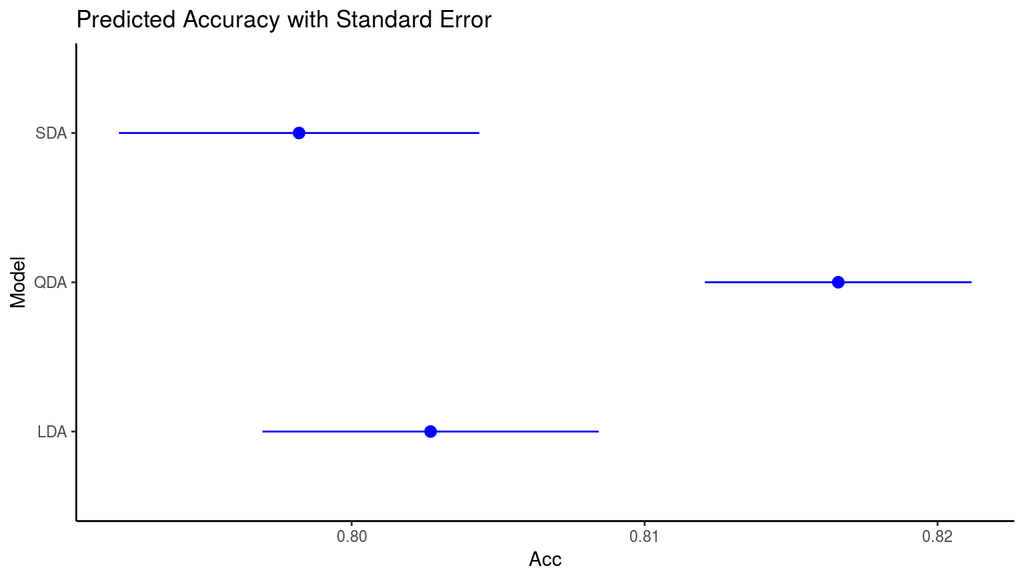

```r
l <- lapply(CV, function(i) { data.frame(Acc = i$stat, se = i$stat.se) })
res <- do.call(rbind, l)
res$Model <- rownames(res)
ggplot(res, aes(x = Model, y = Acc)) +
  geom_pointrange(aes(ymax = Acc + se, ymin = Acc - se), color = "blue") +
  coord_flip() +
  ggtitle("Predicted Accuracy with Standard Error") +
  theme_classic()
```

# 4 Prediction

## 4.1 Final Model

We estimated that the *QDA* procedure with forward feature selection gives the best prediction accuracy. Now this is applied on the whole training set.

```r
# estimate best feature combination with CV
steps <- stepclass(
  Xtrain, grouping = Ytrain,
  improvement = 0, method = "qda", direction = "forward",
  fold = 5, output = FALSE
)

# fit model with selected features
idx <- which.max(steps$process$result.pm)
feats <- as.character(steps$process$varname[1:idx])
redXtrain <- Xtrain[, colnames(Xtrain) %in% feats[-1]]
fit <- qda(redXtrain, grouping = Ytrain)
```

We can look at the final model. There is a prior of roughly 60% non-survivors to 40% survivors. From the group means table you can see which features are used.

```r
fit
```

```
## Call:
## qda(redXtrain, grouping = Ytrain)
##
## Prior probabilities of groups:
##         0         1
## 0.6161616 0.3838384
##
## Group means:
##      isMale      isU14 FMembers smallFamily
## 0 0.8524590 0.07832423 1.883424   0.2240437
## 1 0.3187135 0.14327485 1.938596   0.4941520
```

## 4.2 Predict Test Set

Now the model is finally used on the test dataset.

```r
redXtest <- Xtest[, colnames(Xtest) %in% feats[-1]]
pred <- predict(fit, newdata = redXtest)
```

The posterior probability distribution is shown below. For each passenger the class with the highest probability is chosen. As you can see the model is quite sure about its decision. There are no cases near 0.5.

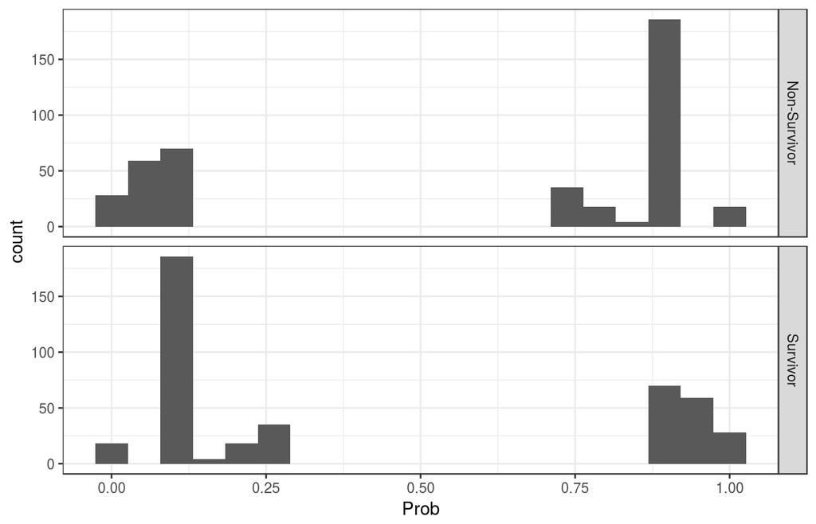

```r
df <- data.frame(
  Prob = c(pred$posterior[, 1], pred$posterior[, 2]),
  Class = rep(c("Non-Survivor", "Survivor"), each = nrow(pred$posterior))
)
ggplot(df, aes(x = Prob)) +
  geom_histogram(bins = 20) +
  facet_grid(Class ~ .) +
  theme_bw()
```

These are the predictions…

```r
df <- data.frame(
  PassengerId = rownames(pred$posterior),
  Survived = pred$class
)
write.csv(df, file = "QDA_submission.csv", row.names = FALSE, quote = FALSE)
table(df$Survived)
```

```
##
##   0   1
## 261 157
```

That’s it! Thanks for reading through this whole thing. If you have any suggestions, comments are welcome.